# Self-Driving Car Engineer Nanodegree

## Project: Build a Traffic Sign Recognition Classifier

In this notebook, a template is provided for you to implement your functionality in stages which is required to successfully complete this project. If additional code is required that cannot be included in the notebook, be sure that the Python code is successfully imported and included in your submission, if necessary. Sections that begin with **'Implementation'** in the header indicate where you should begin your implementation for your project. Note that some sections of implementation are optional, and will be marked with **'Optional'** in the header.

In addition to implementing code, there will be questions that you must answer which relate to the project and your implementation. Each section where you will answer a question is preceded by a **'Question'** header. Carefully read each question and provide thorough answers in the following text boxes that begin with **'Answer:'**. Your project submission will be evaluated based on your answers to each of the questions and the implementation you provide.

> **Note:** Code and Markdown cells can be executed using the **Shift + Enter** keyboard shortcut. In addition, Markdown cells can be edited by typically double-clicking the cell to enter edit mode.

## Step 0: Load The Data

```python
# Load pickled data
import pickle

# TODO: Fill this in based on where you saved the training and testing data

training_file = './data/train.p'
testing_file = './data/test.p'

with open(training_file, mode='rb') as f:
    train = pickle.load(f)
with open(testing_file, mode='rb') as f:
    test = pickle.load(f)

X_train, y_train = train['features'], train['labels']
X_test, y_test = test['features'], test['labels']
```

## Step 1: Dataset Summary & Exploration

The pickled data is a dictionary with 4 key/value pairs:

- `'features'` is a 4D array containing raw pixel data of the traffic sign images, (num examples, width, height, channels).
- `'labels'` is a 1D array containing the label/class id of the traffic sign. The file `signnames.csv` contains id -> name mappings for each id.
- `'sizes'` is a list containing tuples, (width, height) representing the the original width and height the image.
- `'coords'` is a list containing tuples, (x1, y1, x2, y2) representing coordinates of a bounding box around the sign in the image. **THESE COORDINATES ASSUME THE ORIGINAL IMAGE. THE PICKLED DATA CONTAINS RESIZED VERSIONS (32 by 32) OF THESE IMAGES**

Complete the basic data summary below.

```python
### Replace each question mark with the appropriate value.
import numpy as np
import pandas as pd

# TODO: Number of training examples
n_train = X_train.shape[0]

# TODO: Number of testing examples.
n_test = X_test.shape[0]

# TODO: What's the shape of an traffic sign image?
image_shape = X_train[0].shape

# TODO: How many unique classes/labels there are in the dataset.
n_classes = len(np.unique(y_train))

print("Number of training examples =", n_train)
print("Number of testing examples =", n_test)
print("Image data shape =", image_shape)
print("Number of classes =", n_classes)
```

```
Number of training examples = 39209
Number of testing examples = 12630
Image data shape = (32, 32, 3)
Number of classes = 43
```

```python
classes = pd.read_csv('signnames.csv')

print(classes.head())
```

```
   ClassId              SignName
0        0  Speed limit (20km/h)
1        1  Speed limit (30km/h)
2        2  Speed limit (50km/h)
3        3  Speed limit (60km/h)
4        4  Speed limit (70km/h)
```

```python
classes.SignName[0]
```

```
'Speed limit (20km/h)'
```

Visualize the German Traffic Signs Dataset using the pickled file(s). This is open ended, suggestions include: plotting traffic sign images, plotting the count of each sign, etc.

The [Matplotlib](http://matplotlib.org/) [examples](http://matplotlib.org/examples/index.html) and [gallery](http://matplotlib.org/gallery.html) pages are a great resource for doing visualizations in Python.

**NOTE:** It's recommended you start with something simple first. If you wish to do more, come back to it after you've completed the rest of the sections.

```python
### Data exploration visualization goes here.
### Feel free to use as many code cells as needed.
import matplotlib.pyplot as plt
# Visualizations will be shown in the notebook.
%matplotlib inline
```

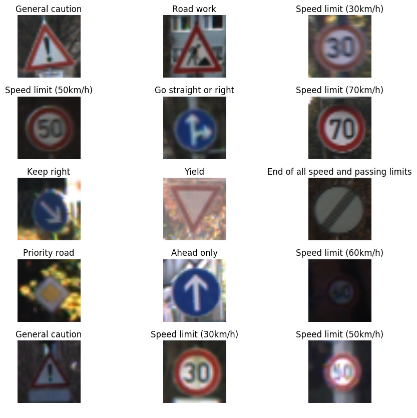

```python
import random

num_vertical = 5
num_horizontal = 3

fig, axs = plt.subplots(num_vertical, num_horizontal, figsize=(10, 10))
fig.subplots_adjust(hspace = .3, wspace=.5)
axs = axs.ravel()
for i in range(num_vertical * num_horizontal):
    index = random.randint(0, len(X_train))
    image = X_train[index]
    axs[i].axis('off')
    axs[i].imshow(image)
    axs[i].set_title(classes.SignName[y_train[index]])
```

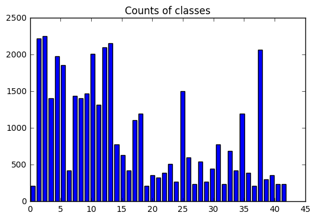

```python
hist, bins = np.histogram(y_train, bins=n_classes)
width = 0.7 * (bins[1] - bins[0])
center = (bins[:-1] + bins[1:]) / 2
plt.title('Counts of classes')
plt.bar(center, hist, align='center', width=width)
plt.show()
```

## Step 2: Design and Test a Model Architecture

Design and implement a deep learning model that learns to recognize traffic signs. Train and test your model on the [German Traffic Sign Dataset](http://benchmark.ini.rub.de/?section=gtsrb&subsection=dataset).

There are various aspects to consider when thinking about this problem:

- Neural network architecture
- Play around preprocessing techniques (normalization, rgb to grayscale, etc)
- Number of examples per label (some have more than others).
- Generate fake data.

Here is an example of a [published baseline model on this problem](http://yann.lecun.com/exdb/publis/pdf/sermanet-ijcnn-11.pdf). It's not required to be familiar with the approach used in the paper but, it's good practice to try to read papers like these.

**NOTE:** The LeNet-5 implementation shown in the classroom at the end of the CNN lesson is a solid starting point. You'll have to change the number of classes and possibly the preprocessing, but aside from that it's plug and play!

### Implementation

Use the code cell (or multiple code cells, if necessary) to implement the first step of your project. Once you have completed your implementation and are satisfied with the results, be sure to thoroughly answer the questions that follow.

```python
### Preprocess the data here.
### Feel free to use as many code cells as needed.
import cv2

def yuv_process(img):
    yuv = cv2.cvtColor(img, cv2.COLOR_RGB2YUV)
    y = yuv[:,:,0]

    # create a CLAHE object
    clahe = cv2.createCLAHE(clipLimit=1.5, tileGridSize=(3,3))
    _y = clahe.apply(y)
    yuv[:,:,0] = _y

    new_img = cv2.cvtColor(yuv, cv2.COLOR_YUV2RGB)

    return new_img

def gray_scale(X):
    return np.sum(X/3, axis=3, keepdims=True)

def standardize(X):
    # Input: an array of images
    # Output: return the corresponding standardized gray scale array of those images

    X = gray_scale(X)
    return (X - np.mean(X, axis=0)) / np.std(X, axis=0)


def min_max_scale(X, min_value = -1, max_value = 1):
    # Input: an array of images
    # Output: return the corresponding normalized gray scale array of those images

    X = gray_scale(X)
    X = (X - X.min(axis=0)) / (X.max(axis=0) - X.min(axis=0))
    X = X * (max_value - min_value) + min_value

    return X
```

```python
X_train = X_train.astype(np.uint8)
X_train_processed = np.array([yuv_process(img) for img in X_train])
X_train_normalized = standardize(X_train_processed)
X_train_minmaxed = min_max_scale(X_train_processed)

X_test = X_test.astype(np.uint8)
X_test_processed = np.array([yuv_process(img) for img in X_test])
X_test_normalized = standardize(X_test_processed)
X_test_minmaxed = min_max_scale(X_test_processed)

print("----------------------")
print("train shape:", X_train.shape)
print("grayscale train shape:", X_train_processed.shape)
print("train normalized shape:", X_train_normalized.shape)
print("train min-max scaling shape:", X_train_minmaxed.shape)

print("----------------------")
print("test shape:", X_test.shape)
print("grayscale test shape:", X_train_processed.shape)
print("normalized test shape:", X_test_normalized.shape)
print("train min-max scaling shape:", X_test_minmaxed.shape)
```

```
----------------------
train shape: (39209, 32, 32, 3)
grayscale train shape: (39209, 32, 32, 3)
train normalized shape: (39209, 32, 32, 1)
train min-max scaling shape: (39209, 32, 32, 1)
----------------------
test shape: (12630, 32, 32, 3)
grayscale test shape: (39209, 32, 32, 3)
normalized test shape: (12630, 32, 32, 1)
train min-max scaling shape: (12630, 32, 32, 1)
```

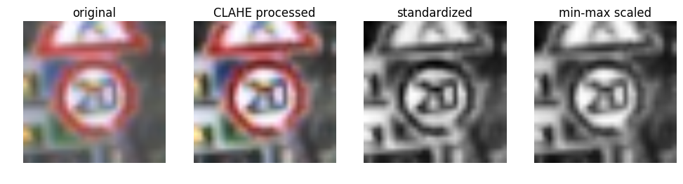

```python
fig, axs = plt.subplots(1, 4, figsize=(12, 12))

axs[0].axis('off')
axs[0].set_title('original')
axs[0].imshow(X_train[0].squeeze())

axs[1].axis('off')
axs[1].set_title('CLAHE processed')
axs[1].imshow(X_train_processed[0].squeeze())

axs[2].axis('off')
axs[2].set_title('standardized')
axs[2].imshow(X_train_normalized[0].squeeze(), cmap='gray')

axs[3].axis('off')
axs[3].set_title('min-max scaled')
axs[3].imshow(X_train_minmaxed[0].squeeze(), cmap='gray')
```

```python
# clean up
del X_train_processed, X_train_minmaxed, X_test_processed, X_test_minmaxed
```

### Question 1

*Describe how you preprocessed the data. Why did you choose that technique?*

**Answer:**

#### 1. Converting images to YUV channel. Applying Contrast Limited Adaptive Histogram Equalization (CLAHE) to Y.

We convert all images to YUV space. The Y channel is then preprocessed with global and local contrast normalization while U and V channels are left unchanged.

These two methods are originated from Sermanet and LeCunn's [paper](http://yann.lecun.com/exdb/publis/pdf/sermanet-ijcnn-11.pdf), and are implemented in the **yuv_process** method above.

#### 2. Averaging pixel intensity over channels (grayscaling).

Since all classes are identified to others by their shape, color is not relevant. We then average the all the color channels. This also helps reduce the dimensionality of the data by three times and helps the model converges.

That is exactly what the **gray_scale** does above.

#### 3. Standardizing/Min-max scaling images.

This is just basically mean substraction and normalization, as we want the data to have zero mean and unit standard deviation. Another form of this method is to preprocess each dimension so that the min and max along the dimension is -1 and 1 respectively.

These methods are implemented in the **standardize** and **min_max_scale** methods.

```python
### Generate additional data (OPTIONAL!)
### and split the data into training/validation/testing sets here.
### Feel free to use as many code cells as needed.

import cv2

def translate(img):
    ny, nx, _ = img.shape

    px = 2
    dx, dy = np.random.randint(-px, px, 2)

    M = np.float32([[1, 0, dx], [0, 1, dy]])
    new_img = cv2.warpAffine(img, M, (nx, ny))

    new_img = new_img[:,:,np.newaxis]

    return new_img

def scale(img):
    ny, nx, _ = img.shape
    px = np.random.randint(-2,2)

    # ending vertices
    vertices = np.float32([[px,px], [ny-px,px], [px,nx-px], [ny-px,nx-px]])
    corners = np.float32([[0,0], [ny,0], [0, nx], [ny, nx]])

    M = cv2.getPerspectiveTransform(vertices, corners)

    new_img = cv2.warpPerspective(img, M, (nx, ny))
    new_img = new_img[:,:,np.newaxis]

    return new_img

def rotate(img):
    nx, ny, _ = img.shape

    # random scalar/degree
    rand_x = np.random.rand(3) - 0.5
    rand_x *= nx * 0.1
    rand_y = np.random.rand(3) - 0.5
    rand_y *= ny * 0.1

    # get 3 starting points for transform
    # which are 1/4 way from edges
    x1, x2 = nx/4, 3*nx/4
    y1, y2 = ny/4, 3*ny/4

    # getting the transformer vertices
    vertices_1 = np.float32([[y1,x1], [y2,x1], [y1,x2]])
    vertices_2 = np.float32([[y1+rand_y[0], x1+rand_x[0]],
                             [y2+rand_y[1], x1+rand_x[1]],
                             [y1+rand_y[2], x2+rand_x[2]]])

    M = cv2.getAffineTransform(vertices_1, vertices_2)

    new_img = cv2.warpAffine(img, M, (nx, ny))

    new_img = new_img[:,:,np.newaxis]

    return new_img

def jitter(img):
    shifted_img = img + 1.0
    max_value = max(shifted_img.flatten())

    max_coef = 2.0 / max_value
    min_coef = max_coef - 0.5

    coef = np.random.uniform(min_coef, max_coef)
    new_img = shifted_img * coef - 1.0

    return new_img
```

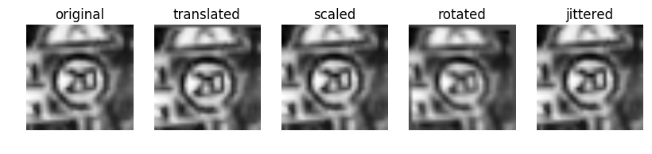

```python
test_img = X_train_normalized[0]

test_translate = translate(test_img)
test_scale = scale(test_img)
test_rotate = rotate(test_img)
test_jitter = jitter(test_img)

fig, axs = plt.subplots(1, 5, figsize=(10, 10))

axs[0].axis('off')
axs[0].imshow(test_img.squeeze(), cmap='gray')
axs[0].set_title('original')

axs[1].axis('off')
axs[1].imshow(test_translate.squeeze(), cmap='gray')
axs[1].set_title('translated')

axs[2].axis('off')
axs[2].imshow(test_scale.squeeze(), cmap='gray')
axs[2].set_title('scaled')

axs[3].axis('off')
axs[3].imshow(test_rotate.squeeze(), cmap='gray')
axs[3].set_title('rotated')

axs[4].axis('off')
axs[4].imshow(test_jitter.squeeze(), cmap='gray')
axs[4].set_title('jittered')
```

```python
from random import randint

min_threshold = 1000

for _class in range(n_classes):
    indices = np.where(y_train == _class)
    n_samples = len(indices[0])

    if n_samples < min_threshold:
        for i in range(min_threshold - n_samples):
            new_img = X_train_normalized[indices[0][i % n_samples]]

            index = randint(0, 3)
            if index == 0:
                new_img = translate(new_img)
            elif index == 1:
                new_img = scale(new_img)
            elif index == 2:
                new_img = rotate(new_img)
            elif index == 3:
                new_img = jitter(new_img)

            X_train_normalized = np.concatenate((X_train_normalized, [new_img]), axis=0)
            y_train = np.concatenate((y_train, [_class]), axis=0)
```

```python
from sklearn.utils import shuffle
from sklearn.model_selection import train_test_split

X_train_normalized, y_train = shuffle(X_train_normalized, y_train)
X_train, X_valid, y_train, y_valid = train_test_split(X_train_normalized,
                                                      y_train,
                                                      test_size=0.20,
                                                      random_state=1511)
X_test = X_test_normalized

# save for later uses
np.save('./data/X_train', X_train)
np.save('./data/y_train', y_train)
np.save('./data/X_valid', X_valid)
np.save('./data/y_valid', y_valid)
np.save('./data/X_test', X_test)
np.save('./data/y_test', y_test)
```

```python
# load from early sessions
X_train = np.load('./data/X_train.npy')
X_valid = np.load('./data/X_valid.npy')
X_test = np.load('./data/X_test.npy')
y_train = np.load('./data/y_train.npy')
y_valid = np.load('./data/y_valid.npy')
y_test = np.load('./data/y_test.npy')

# assert that the length is correct
print(len(X_train), len(y_train))
print(len(X_valid), len(y_valid))
print(len(X_test), len(y_test))
```

```
43768 43768
10942 10942
12630 12630
```

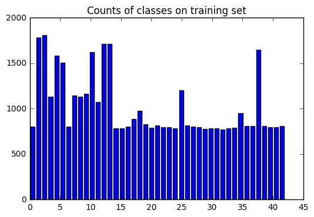

```python
hist, bins = np.histogram(y_train, bins=n_classes)
width = 0.7 * (bins[1] - bins[0])
plt.title('Counts of classes on training set')
center = (bins[:-1] + bins[1:]) / 2
plt.bar(center, hist, align='center', width=width)
plt.show()
```

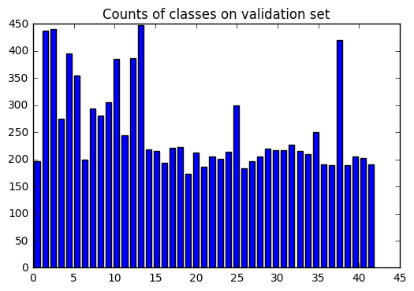

```python
hist, bins = np.histogram(y_valid, bins=n_classes)
width = 0.7 * (bins[1] - bins[0])
plt.title('Counts of classes on validation set')
center = (bins[:-1] + bins[1:]) / 2
plt.bar(center, hist, align='center', width=width)
plt.show()
```

```python
# clean up
del X_train_normalized, X_test_normalized
```

### Question 2

*Describe how you set up the training, validation and testing data for your model. **Optional**: If you generated additional data, how did you generate the data? Why did you generate the data? What are the differences in the new dataset (with generated data) from the original dataset?*

**Answer:**

To save training time, I plan to use static validation set, instead of doing **k-fold cross validation**, which would cost the training time by k times.

The ratio of Training/Validation set is **80/20**. The test set is left as it is after preprocessing.

Since the class ratio is unbalance, as shown above, i.e some classes have more training data than other, one need to apply data augmentation. We will introduce some methods for generating additional data.

1. **Translation**: Translating, by a randomly distance, an image into one out of four directions: Up, Down, Left, Right.
2. **Scaling**: Maximizing or minimizing the image by a random scaler.
3. **Rotation**: Rotating the image by some random small degrees.
4. **Jittering**: Slightly simultaneously randomly changing the value of each pixel.

These methods are implemented above, and there are plots to show the differences between each one.

We will generate images for each class that has the number of samples less than 1000. We get the generated image by applying one of those for data augmentation methods randomly.

The new data set with generated data has **at least 1000 samples for each class**. Basically this means more training data. Later on, we can see how effective this method is.

```python
### Define your architecture here.
### Feel free to use as many code cells as needed.

import tensorflow as tf
from tensorflow.contrib.layers import flatten

# hyperparameters
EPOCHS = 60
BATCH_SIZE = 100
L_RATE = 0.0005

x = tf.placeholder(tf.float32, (None, 32, 32, 1))
y = tf.placeholder(tf.int32, (None))
keep_prob = tf.placeholder(tf.float32) # probability to keep units
one_hot_y = tf.one_hot(y, 43)
```

### Sermanet and LeCun's architecture

```python
def Sermanet(x):
    # Hyperparameters
    mu = 0
    sigma = 0.1

    # Layer 1: Convolutional. Input = 32x32x1. Output = 28x28x6.
    # ReLU Activation.
    # Pooling. Input = 28x28x6. Output = 14x14x6.
    W_1 = tf.Variable(tf.truncated_normal(shape=(5, 5, 1, 6), mean = mu, stddev = sigma), name = "W1")
    x = tf.nn.conv2d(x, W_1, strides=[1, 1, 1, 1], padding = 'VALID')
    b_1 = tf.Variable(tf.zeros(6), name = "b1")
    x = tf.nn.bias_add(x, b_1)
    x = tf.nn.relu(x)
    x = tf.nn.max_pool(x, ksize=[1, 2, 2, 1], strides=[1, 2, 2, 1], padding='VALID')
    layer_1 = x

    # Layer 2: Convolutional. Output = 10x10x16.
    # ReLU Activation (fc)
    # Pooling. Input = 10x10x16. Output = 5x5x16.
    W_2 = tf.Variable(tf.truncated_normal(shape=(5, 5, 6, 16), mean = mu, stddev = sigma), name="W2")
    x = tf.nn.conv2d(x, W_2, strides=[1, 1, 1, 1], padding='VALID')
    b_2 = tf.Variable(tf.zeros(16), name="b2")
    x = tf.nn.bias_add(x, b_2)
    x = tf.nn.relu(x)
    x = tf.nn.max_pool(x, ksize=[1, 2, 2, 1], strides=[1, 2, 2, 1], padding='VALID')
    layer_2 = x

    # Layer 3: Convolutional. Output = 1x1x400.
    # ReLU Activation.
    # Flatten. Input = 5x5x16. Output = 400.
    W_3 = tf.Variable(tf.truncated_normal(shape=(5, 5, 16, 400), mean = mu, stddev = sigma), name="W3")
    x = tf.nn.conv2d(x, W_3, strides=[1, 1, 1, 1], padding='VALID')
    b_3 = tf.Variable(tf.zeros(400), name="b3")
    x = tf.nn.bias_add(x, b_3)
    x = tf.nn.relu(x)
    layer_3 = x

    # Flatten x. Input = 1x1x400. Output = 400.
    # Concat layer_2_flat and x. Input = 400 + 400. Output = 800
    layer_2_flat = flatten(layer_2)
    x_flat = flatten(x)
    x = tf.concat_v2([x_flat, layer_2_flat], 1)

    # Dropout
    x = tf.nn.dropout(x, keep_prob)

    # Layer 4: Fully Connected. Input = 800. Output = 43.
    W_4 = tf.Variable(tf.truncated_normal(shape=(800, n_classes), mean = mu, stddev = sigma), name="W4")
    b_4 = tf.Variable(tf.zeros(n_classes), name="b4")
    logits = tf.add(tf.matmul(x, W_4), b_4)

    return logits
```

### Question 3

*What does your final architecture look like? (Type of model, layers, sizes, connectivity, etc.) For reference on how to build a deep neural network using TensorFlow, see Deep Neural Network in TensorFlow from the classroom.*

**Answer:**

```python
### Train your model here.
### Feel free to use as many code cells as needed.

logits = Sermanet(x)
cross_entropy = tf.nn.softmax_cross_entropy_with_logits(logits, one_hot_y)
loss_operation = tf.reduce_mean(cross_entropy)
optimizer = tf.train.AdamOptimizer(learning_rate = L_RATE)
training_operation = optimizer.minimize(loss_operation)
```

```python
correct_prediction = tf.equal(tf.argmax(logits, 1), tf.argmax(one_hot_y, 1))
accuracy_operation = tf.reduce_mean(tf.cast(correct_prediction, tf.float32))
saver = tf.train.Saver()

def evaluate(X_data, y_data):
    num_examples = len(X_data)
    total_accuracy = 0
    sess = tf.get_default_session()
    for offset in range(0, num_examples, BATCH_SIZE):
        batch_x, batch_y = X_data[offset:offset+BATCH_SIZE], y_data[offset:offset+BATCH_SIZE]
        accuracy = sess.run(accuracy_operation, feed_dict={x: batch_x, y: batch_y, keep_prob: 1.0})
        total_accuracy += (accuracy * len(batch_x))

    return total_accuracy / num_examples
```

```python
from sklearn.utils import shuffle

with tf.Session() as sess:
    sess.run(tf.global_variables_initializer())
    num_examples = len(X_train)

    print('Begin the training process...')
    for i in range(EPOCHS):
        X_train, y_train = shuffle(X_train, y_train)
        for offset in range(0, num_examples, BATCH_SIZE):
            end = offset + BATCH_SIZE
            batch_x, batch_y = X_train[offset:end], y_train[offset:end]
            sess.run(training_operation, feed_dict={x: batch_x, y: batch_y, keep_prob: 0.5})

        validation_accuracy = evaluate(X_valid, y_valid)
        print("epoch %d / %d ... Validation Accuracy = %.3f" %(i+1, EPOCHS, validation_accuracy))

    saver.save(sess, 'sermanet')
```

```
Begin the training process...
epoch 1 / 60 ... Validation Accuracy = 0.864
epoch 2 / 60 ... Validation Accuracy = 0.914
epoch 3 / 60 ... Validation Accuracy = 0.939
epoch 4 / 60 ... Validation Accuracy = 0.953
epoch 5 / 60 ... Validation Accuracy = 0.961
epoch 6 / 60 ... Validation Accuracy = 0.969
epoch 7 / 60 ... Validation Accuracy = 0.972
epoch 8 / 60 ... Validation Accuracy = 0.975
epoch 9 / 60 ... Validation Accuracy = 0.978
epoch 10 / 60 ... Validation Accuracy = 0.982
epoch 11 / 60 ... Validation Accuracy = 0.983
epoch 12 / 60 ... Validation Accuracy = 0.985
epoch 13 / 60 ... Validation Accuracy = 0.986
epoch 14 / 60 ... Validation Accuracy = 0.987
epoch 15 / 60 ... Validation Accuracy = 0.988
epoch 16 / 60 ... Validation Accuracy = 0.987
epoch 17 / 60 ... Validation Accuracy = 0.988
epoch 18 / 60 ... Validation Accuracy = 0.989
epoch 19 / 60 ... Validation Accuracy = 0.990
epoch 20 / 60 ... Validation Accuracy = 0.990
epoch 21 / 60 ... Validation Accuracy = 0.990
epoch 22 / 60 ... Validation Accuracy = 0.990
epoch 23 / 60 ... Validation Accuracy = 0.992
epoch 24 / 60 ... Validation Accuracy = 0.988
epoch 25 / 60 ... Validation Accuracy = 0.991
epoch 26 / 60 ... Validation Accuracy = 0.991
epoch 27 / 60 ... Validation Accuracy = 0.992
epoch 28 / 60 ... Validation Accuracy = 0.992
epoch 29 / 60 ... Validation Accuracy = 0.992
epoch 30 / 60 ... Validation Accuracy = 0.993
epoch 31 / 60 ... Validation Accuracy = 0.994
epoch 32 / 60 ... Validation Accuracy = 0.994
epoch 33 / 60 ... Validation Accuracy = 0.992
epoch 34 / 60 ... Validation Accuracy = 0.992
epoch 35 / 60 ... Validation Accuracy = 0.993
epoch 36 / 60 ... Validation Accuracy = 0.993
epoch 37 / 60 ... Validation Accuracy = 0.994
epoch 38 / 60 ... Validation Accuracy = 0.993
epoch 39 / 60 ... Validation Accuracy = 0.991
epoch 40 / 60 ... Validation Accuracy = 0.993
epoch 41 / 60 ... Validation Accuracy = 0.993
epoch 42 / 60 ... Validation Accuracy = 0.993
epoch 43 / 60 ... Validation Accuracy = 0.992
epoch 44 / 60 ... Validation Accuracy = 0.993
epoch 45 / 60 ... Validation Accuracy = 0.993
epoch 46 / 60 ... Validation Accuracy = 0.994
epoch 47 / 60 ... Validation Accuracy = 0.994
epoch 48 / 60 ... Validation Accuracy = 0.994
epoch 49 / 60 ... Validation Accuracy = 0.994
epoch 50 / 60 ... Validation Accuracy = 0.995
epoch 51 / 60 ... Validation Accuracy = 0.994
epoch 52 / 60 ... Validation Accuracy = 0.994
epoch 53 / 60 ... Validation Accuracy = 0.993
epoch 54 / 60 ... Validation Accuracy = 0.995
epoch 55 / 60 ... Validation Accuracy = 0.995
epoch 56 / 60 ... Validation Accuracy = 0.994
epoch 57 / 60 ... Validation Accuracy = 0.993
epoch 58 / 60 ... Validation Accuracy = 0.993
epoch 59 / 60 ... Validation Accuracy = 0.994
epoch 60 / 60 ... Validation Accuracy = 0.995
```

```python
with tf.Session() as sess:
    sess.run(tf.global_variables_initializer())
    saver2 = tf.train.import_meta_graph('./sermanet.meta')
    saver2.restore(sess, "./sermanet")
    test_accuracy = evaluate(X_test, y_test)
    print("Test Set Accuracy = {:.3f}".format(test_accuracy))
```

```
Test Set Accuracy = 0.950
```

### Question 4

*How did you train your model? (Type of optimizer, batch size, epochs, hyperparameters, etc.)*

### Question 5

*What approach did you take in coming up with a solution to this problem? It may have been a process of trial and error, in which case, outline the steps you took to get to the final solution and why you chose those steps. Perhaps your solution involved an already well known implementation or architecture. In this case, discuss why you think this is suitable for the current problem.*

**Answer of Question 4 and Question 5:**

We follow Sermanet and LeCun's structure from [this article](http://yann.lecun.com/exdb/publis/pdf/sermanet-ijcnn-11.pdf). This system has yield one of the best results at that time, so I think it is a good start.

In detail, this is what the network looks like:

[figure not shown]

The layers are set up as below:

```
1. Convolutional layer (32x32x1 in, 28x28x6 out) - ReLU activation - Max Pooling (28x28x6 in, 14x14x6 out)
2. Convolutional layer (14x14x6 in, 10x10x16 out) - ReLU activation (fully connected) - Max Pooling (10x10x16 in, 5x5x16 out)
3. Convolutional layer (5x5x16 in, 1x1x400 out) - ReLU activation (fully connected)
4. Concaternation of the second convolutional layer and the third convolutional layer (5x5x16 and 1x400 in, 800 out) - Dropout with keep_prob
5. Fully Connected (800 in, 43 (= n_classes) out)
```

For the hyperparameters, we train the network with **60 epochs** of **batch size 100**. We also use **Adam optimizer** with a **learning rate of 0.0005**.

## Step 3: Test a Model on New Images

Take several pictures of traffic signs that you find on the web or around you (at least five), and run them through your classifier on your computer to produce example results. The classifier might not recognize some local signs but it could prove interesting nonetheless.

You may find `signnames.csv` useful as it contains mappings from the class id (integer) to the actual sign name.

### Implementation

Use the code cell (or multiple code cells, if necessary) to implement the first step of your project. Once you have completed your implementation and are satisfied with the results, be sure to thoroughly answer the questions that follow.

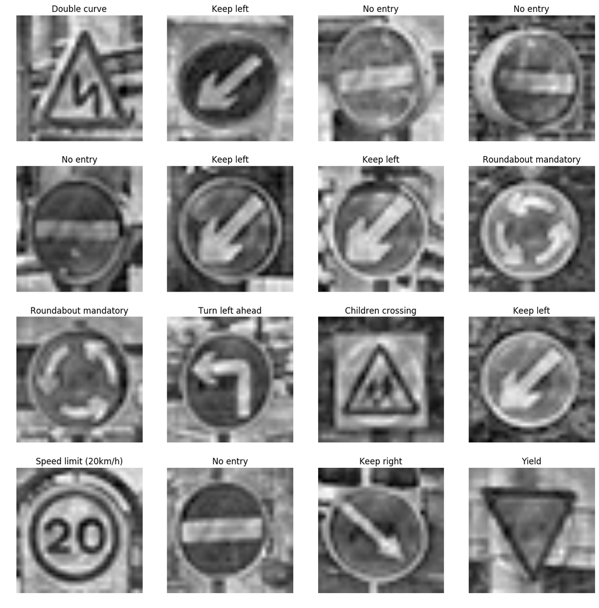

```python
### Load the images and plot them here.
### Feel free to use as many code cells as needed.

import glob
import matplotlib.image as mpimg

fig, axs = plt.subplots(4, 4, figsize=(15, 15))
fig.subplots_adjust(hspace = .2, wspace=.2)
axs = axs.ravel()

local_images = []
local_labels = [
    21, # "example_00001"
    39, # "example_00002"
    17, # "example_00003"
    17, # "example_00004"
    17, # "example_00005"
    39, # "example_00006"
    39, # "example_00007"
    40, # "example_00008"
    40, # "example_00009"
    34, # "example_00010"
    28, # "example_00011"
    39, # "example_00012"
    0, # "example_00013"
    17, # "example_00014"
    38, # "example_00015"
    13, # "example_00016"
]

for i, img in enumerate(glob.glob('./data/custom/*.png')):
    image = cv2.imread(img)
    image = cv2.resize(image, (32, 32))
    local_images.append(image)

local_images = np.array([yuv_process(image) for image in local_images])
local_images = standardize(np.array(local_images))

for i in range(len(local_images)):
    axs[i].axis('off')
    axs[i].set_title(classes.SignName[local_labels[i]])
    axs[i].imshow(local_images[i].squeeze(), cmap='gray')
```

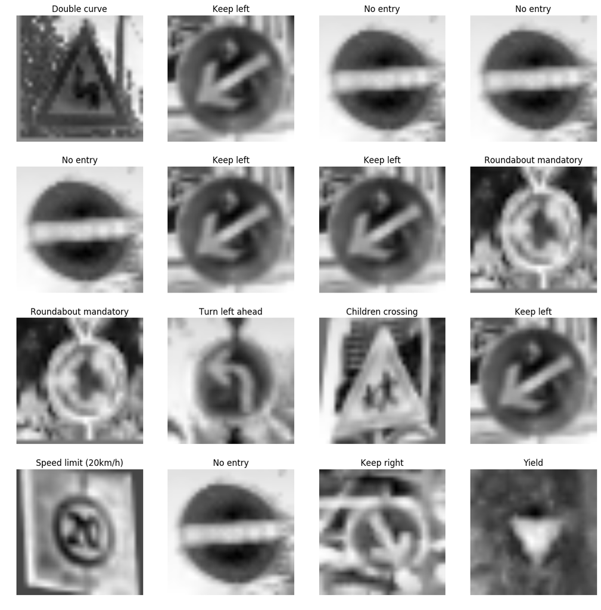

```python
# Corresponding traffic signs in our dataset

fig, axs = plt.subplots(4, 4, figsize=(15, 15))
fig.subplots_adjust(hspace = .2, wspace=.2)
axs = axs.ravel()

for i in range(len(local_images)):
    axs[i].axis('off')
    axs[i].set_title(classes.SignName[local_labels[i]])
    axs[i].imshow(X_train[np.argwhere(y_train == local_labels[i])[10]].squeeze(), cmap='gray')
```

### Question 6

*Choose five candidate images of traffic signs and provide them in the report. Are there any particular qualities of the image(s) that might make classification difficult? It could be helpful to plot the images in the notebook.*

**Answer:**

The data I get is from this [repo](https://github.com/navoshta/traffic-signs/), as suggested in the SDC's Slack channel.

The dataset is **a mix of UK and non-EU signs**, which make the classification task more difficult. However, the main challenge from this dataset is that most of them are **rotate/distort in 3D**.

This is a good dataset to test whether our classifier is **rotational variant** or not.

```python
### Run the predictions here.
### Feel free to use as many code cells as needed.

with tf.Session() as sess:
    sess.run(tf.global_variables_initializer())
    saver3 = tf.train.import_meta_graph('./sermanet.meta')
    saver3.restore(sess, "./sermanet")

    local_accuracy = evaluate(local_images, local_labels)
    print("Local Set Accuracy = {:.3f}".format(local_accuracy))
```

```
Local Set Accuracy = 0.812
```

### Question 7

*Is your model able to perform equally well on captured pictures when compared to testing on the dataset? The simplest way to do this check the accuracy of the predictions. For example, if the model predicted 1 out of 5 signs correctly, it's 20% accurate.*

**NOTE:** You could check the accuracy manually by using `signnames.csv` (same directory). This file has a mapping from the class id (0-42) to the corresponding sign name. So, you could take the class id the model outputs, lookup the name in `signnames.csv` and see if it matches the sign from the image.

**Answer:** The **accuracy for the local test set is 81.2%**, and I'm happy with that score.

### Question 8

*Use the model's softmax probabilities to visualize the **certainty** of its predictions, [`tf.nn.top_k`](https://www.tensorflow.org/versions/r0.12/api_docs/python/nn.html#top_k) could prove helpful here. Which predictions is the model certain of? Uncertain? If the model was incorrect in its initial prediction, does the correct prediction appear in the top k? (k should be 5 at most)*

`tf.nn.top_k` will return the values and indices (class ids) of the top k predictions. So if k=3, for each sign, it'll return the 3 largest probabilities (out of a possible 43) and the correspoding class ids.

Take this numpy array as an example:

```
# (5, 6) array
a = np.array([[ 0.24879643,  0.07032244,  0.12641572,  0.34763842,  0.07893497,
         0.12789202],
       [ 0.28086119,  0.27569815,  0.08594638,  0.0178669 ,  0.18063401,
         0.15899337],
       [ 0.26076848,  0.23664738,  0.08020603,  0.07001922,  0.1134371 ,
         0.23892179],
       [ 0.11943333,  0.29198961,  0.02605103,  0.26234032,  0.1351348 ,
         0.16505091],
       [ 0.09561176,  0.34396535,  0.0643941 ,  0.16240774,  0.24206137,
         0.09155967]])
```

Running it through `sess.run(tf.nn.top_k(tf.constant(a), k=3))` produces:

```
TopKV2(values=array([[ 0.34763842,  0.24879643,  0.12789202],
       [ 0.28086119,  0.27569815,  0.18063401],
       [ 0.26076848,  0.23892179,  0.23664738],
       [ 0.29198961,  0.26234032,  0.16505091],
       [ 0.34396535,  0.24206137,  0.16240774]]), indices=array([[3, 0, 5],
       [0, 1, 4],
       [0, 5, 1],
       [1, 3, 5],
       [1, 4, 3]], dtype=int32))
```

Looking just at the first row we get `[ 0.34763842, 0.24879643, 0.12789202]`, you can confirm these are the 3 largest probabilities in `a`. You'll also notice `[3, 0, 5]` are the corresponding indices.

**Answer:**

I have plotted all the result below. The image from the local test set is placed in the left-most, and in the right is the **top-3 predictions** from the classifier.

It seems that the classifier **get all of it correct within 3-classes**, and passes the **rotational variant** test.

```python
### Visualize the softmax probabilities here.
### Feel free to use as many code cells as needed.

softmax_logits = tf.nn.softmax(logits)
top_k = tf.nn.top_k(softmax_logits, k=3)

with tf.Session() as sess:
    sess.run(tf.global_variables_initializer())
    saver = tf.train.import_meta_graph('./sermanet.meta')
    saver.restore(sess, "./sermanet")

    local_softmax_logits = sess.run(softmax_logits, feed_dict={x: local_images, keep_prob: 1.0})
    local_top_k = sess.run(top_k, feed_dict={x: local_images, keep_prob: 1.0})
```

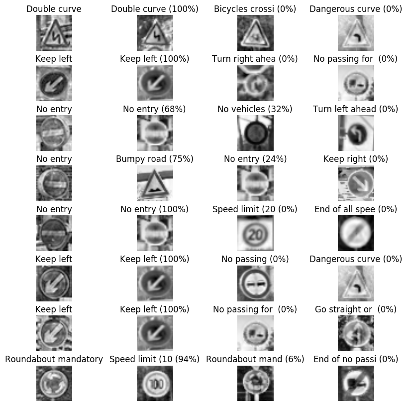

```python
fig, axs = plt.subplots(8, 4, figsize=(10, 10))
fig.subplots_adjust(hspace = .4, wspace=.2)
axs = axs.ravel()

for i, image in enumerate(local_images[:8]):
    indices = [
        np.argwhere(y_valid == local_top_k[1][i][0])[0],
        np.argwhere(y_valid == local_top_k[1][i][1])[0],
        np.argwhere(y_valid == local_top_k[1][i][2])[0]
    ]

    names = [
        classes.SignName[local_top_k[1][i][0]][:15],
        classes.SignName[local_top_k[1][i][1]][:15],
        classes.SignName[local_top_k[1][i][2]][:15]
    ]

    axs[4*i].axis('off')
    axs[4*i].imshow(image.squeeze(), cmap='gray')
    axs[4*i].set_title(classes.SignName[local_labels[i]])

    axs[4*i+1].axis('off')
    axs[4*i+1].imshow(X_valid[indices[0]].squeeze(), cmap='gray')
    axs[4*i+1].set_title('{} ({:.0f}%)'.format(names[0], 100*local_top_k[0][i][0]))

    axs[4*i+2].axis('off')
    axs[4*i+2].imshow(X_valid[indices[1]].squeeze(), cmap='gray')
    axs[4*i+2].set_title('{} ({:.0f}%)'.format(names[1], 100*local_top_k[0][i][1]))

    axs[4*i+3].axis('off')
    axs[4*i+3].imshow(X_valid[indices[2]].squeeze(), cmap='gray')
    axs[4*i+3].set_title('{} ({:.0f}%)'.format(names[2], 100*local_top_k[0][i][2]))
```

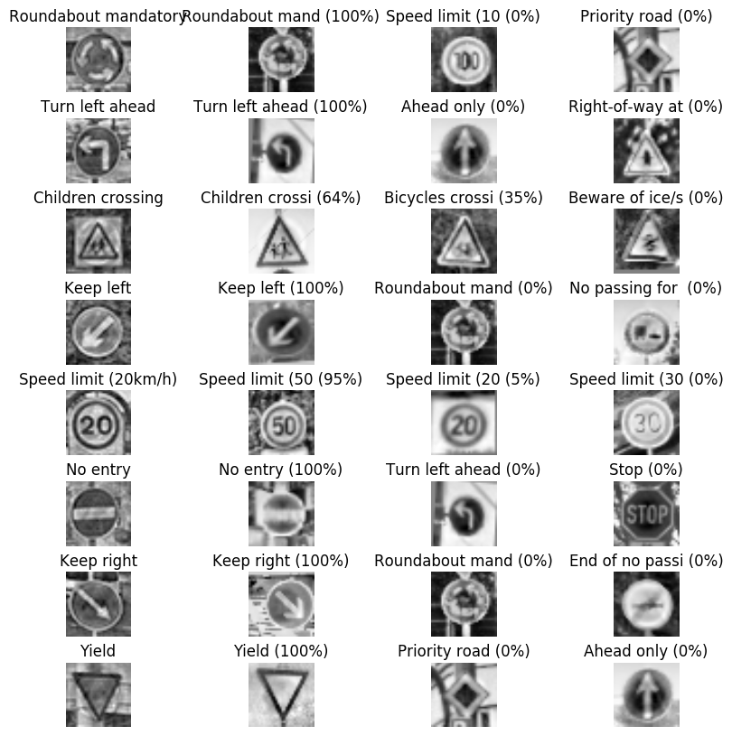

```python
fig, axs = plt.subplots(8, 4, figsize=(10, 10))
fig.subplots_adjust(hspace = .4, wspace=.2)
axs = axs.ravel()

for i, image in enumerate(local_images[8:]):
    indices = [
        np.argwhere(y_valid == local_top_k[1][8+i][0])[0],
        np.argwhere(y_valid == local_top_k[1][8+i][1])[0],
        np.argwhere(y_valid == local_top_k[1][8+i][2])[0]
    ]

    names = [
        classes.SignName[local_top_k[1][8+i][0]][:15],
        classes.SignName[local_top_k[1][8+i][1]][:15],
        classes.SignName[local_top_k[1][8+i][2]][:15]
    ]

    axs[4*i].axis('off')
    axs[4*i].imshow(image.squeeze(), cmap='gray')
    axs[4*i].set_title(classes.SignName[local_labels[8+i]])

    axs[4*i+1].axis('off')
    axs[4*i+1].imshow(X_valid[indices[0]].squeeze(), cmap='gray')
    axs[4*i+1].set_title('{} ({:.0f}%)'.format(names[0], 100*local_top_k[0][8+i][0]))

    axs[4*i+2].axis('off')
    axs[4*i+2].imshow(X_valid[indices[1]].squeeze(), cmap='gray')
    axs[4*i+2].set_title('{} ({:.0f}%)'.format(names[1], 100*local_top_k[0][8+i][1]))

    axs[4*i+3].axis('off')
    axs[4*i+3].imshow(X_valid[indices[2]].squeeze(), cmap='gray')
    axs[4*i+3].set_title('{} ({:.0f}%)'.format(names[2], 100*local_top_k[0][8+i][2]))
```